# Basir Talayee

Entrepreneur, Founder, Storyteller, and Lifelong Learner

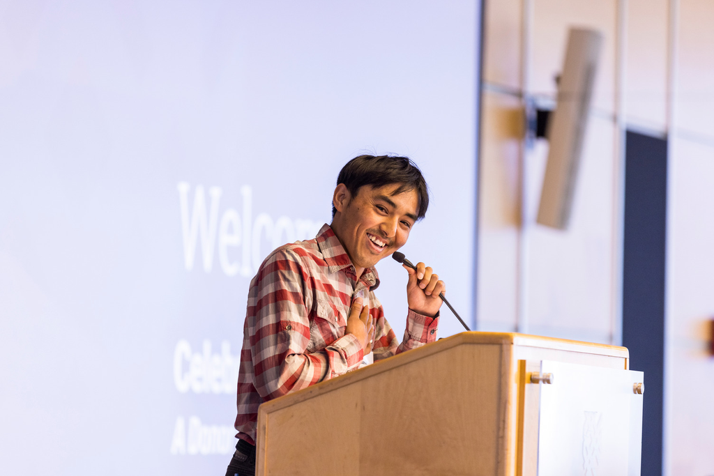

Representing EmpowerEdX at Macalester College’s 150th Reunion -2024

The wine of gratitude is the path to divine intoxication. Remember, everything is perfect, yet there is always room for improvement. Observe, learn, and act in the present moment. Breathe, smile, and cherish this moment, because this moment is your life.

As a lifelong learner, my adventures from **Afghanistan to China, Qatar, and the USA** have been driven by a strong commitment to curiosity, learning, service, innovation, and initiating impactful change.

Equipped with insights from a diverse background in psychology, communication, journalism, marketing, business, cognitive science, epistemology, history, education, theater, Afghan culture, Sufism, Zen Buddhism, and global citizenship, I leverage my knowledge, skills, and real-life experiences to foster a vibrant entrepreneurial and educational ecosystem and serve others.

We all come from unique backgrounds and carry stories that are uniquely ours. **Curiosity** is my beloved guide, helping me learn, ask better questions, practice courage, compassion, and build connections.

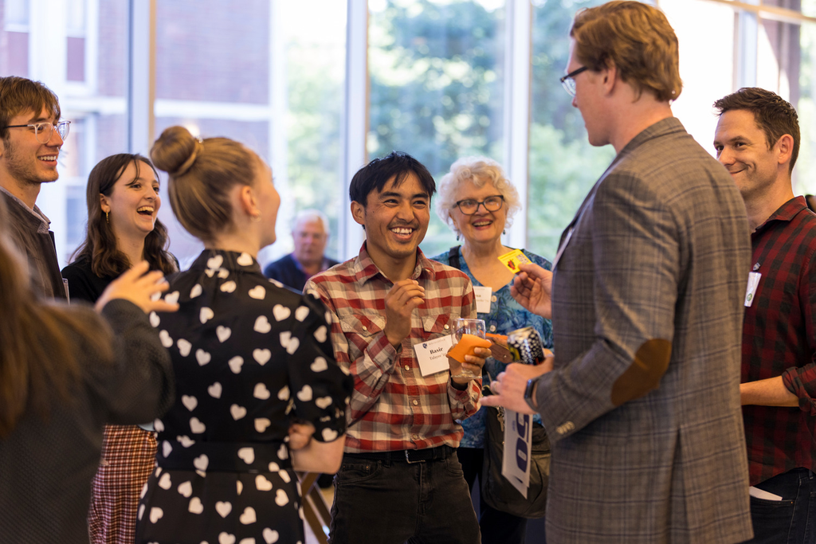

Representing EmpowerEdX at Macalester College’s 150th Reunion

“Connection is why we’re here; it is what gives purpose and meaning to our lives.” – Brené Brown

**I’m glad our paths crossed!**

## Contact

- [Linkedin](https://www.linkedin.com/in/basir-talayee/)
- Email: btalayee@macalester.edu